# Partitionnement sur les données

Manon MAHEO - Valentin PENISSON

11/01/2022

```r
# Installations nécessaires
# https://cran.r-project.org/web/packages/dbscan/readme/README.html

library(dbscan)
library(ggpubr)
library(factoextra)
library(ggplot2)
library(fpc)
```

## Exercice 1 (Jeux de données de petite dimension).

### Importation des données

Nous allons travailler sur le jeu de données **Lsun.lrn**. On utilise également le fichier **Lsun.cls** pour obtenir les labels.

```r
lsun <-  read.csv(file = "Lsun.lrn", header = FALSE, sep = "\t", skip = 4)[,-1]
head(lsun)
```

|  | V2 | V3 |
| --- | --- | --- |
| 1 | 3.277701 | 0.814082 |
| 2 | 0.387577 | 0.176780 |
| 3 | 0.268546 | 0.582963 |
| 4 | 2.031145 | 0.244597 |
| 5 | 0.188677 | 0.461280 |
| 6 | 3.525472 | 0.265579 |

```r
# on enlève les 4 premières lignes du fichier avec skip = 4 et on ne conserve pas l'index des lignes en retirant la première colonne
```

```r
# Importation des labels

labels <-  as.factor(read.csv(file = "Lsun.cls", header = FALSE, sep = "\t",skip = 1)[,-c(1,3)])
head(labels)
```

```
[1] 1 1 1 1 1 1
Levels: 1 2 3
```

```r
# Fusion et création de notre jeu de données

data <-  data.frame(x = lsun[,1], y = lsun[,2], labels = as.factor(labels))
head(data)
```

|  | x | y | labels |
| --- | --- | --- | --- |
| 1 | 3.277701 | 0.814082 | 1 |
| 2 | 0.387577 | 0.176780 | 1 |
| 3 | 0.268546 | 0.582963 | 1 |
| 4 | 2.031145 | 0.244597 | 1 |
| 5 | 0.188677 | 0.461280 | 1 |
| 6 | 3.525472 | 0.265579 | 1 |

Notre jeu de données data contient ainsi des données 2D avec trois classes distinctes (i.e classe 1, 2 et 3). L’ensemble de données se compose donc de n = 400 points dans trois groupes distincts sur un plan.

```r
# Visualisation des données

graph <- ggplot(data = data, aes(x=x, y =y)) + geom_point(aes(color = true_label)) + ggtitle("Original data")
graph
```

[output not shown]

Deux classes sont dessinées uniformément réparties à l’intérieur d’un rectangle de 1 × 4. Ces classes sont disposées sous la forme d’un « L » avec un espace entre les deux. Le troisième groupe est tiré d’une gaussienne standard bidimensionnelle indépendante et identiquement distribuée centrée en (3,2.5). Les classes sont bien séparées par une distance minimale de 0,6 et les classes sont linéairement séparables.

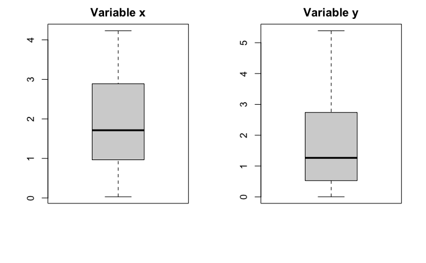

```r
par(mfrow=c(1,2))
for (i in 1:2) boxplot(data[,i], main=paste("Variable ",names(data)[i],sep=""))
```

### Question 1 : Implémenter deux méthodes de partitionnement de votre choix (i.e. méthode de classification non supervisée vue en cours)

#### Méthode 1 : K-means

```r
# On implémente ici la méthode k-means
# On choisit k = 3 car il y a trois labels différents
set.seed(123)
res.km <- kmeans(data[,1:2], 3 , nstart = 25)
predict_label.km <- as.character(res.km$cluster)
```

#### Méthode 2 : DBSCAN (clustering basé sur la densité)

```r
# On implémente ici la méthode dbscan
set.seed(123)
res.dbscan <- dbscan(data[,1:2], eps = 0.5, MinPts = 2)
predict_label.dbscan <- as.factor(res.dbscan$cluster)
```

### Question 2 : Bien présenter les résultats obtenus, les comparer visuellement aux vraies étiquettes lorsqu’elles sont connues.

#### Méthode 1 : K-means

```r
# Visualisation du partitionnement avec kmeans

graph
```

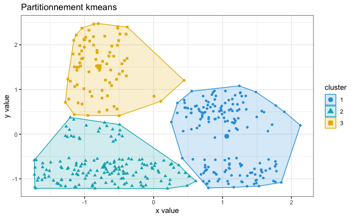

```r
fviz_cluster(res.km, data = data[,1:2],
             palette = c("#2E9FDF", "#00AFBB", "#E7B800"),
             geom = "point",
             ellipse.type = "convex",
             ggtheme = theme_bw(),
             main = "Partitionnement kmeans"
             )
```

#### Méthode 2 : DBSCAN (clustering basé sur la densité)

```r
# Visualisation du partitionnement avec dbscan

graph
```

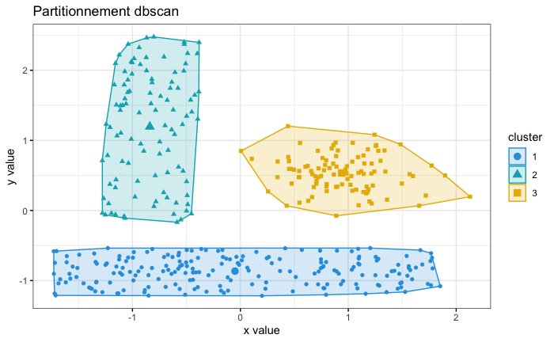

```r
fviz_cluster(res.dbscan, data = data[,1:2],
             palette = c("#2E9FDF", "#00AFBB", "#E7B800"),
             geom = "point",
             ellipse.type = "convex",
             ggtheme = theme_bw(),
             main = "Partitionnement dbscan"
             )
```

La méthode dbscan, quant à elle, classe parfaitement chaque individu dans leur classe respective.

### Question 3 : Pour chacune des méthodes utilisées, expliquer son fonctionnement

#### Méthode 1 : k-means

L’algorithme des k-means est un algorithme de classification non supervisée, c’est à dire qu’à partir simplement de données explicatives ‘X’, il définit des k groupes. En effet, la classification a pour objectif de consituter des groupes aussi homogènes que possible tout en étant bien distinctement séparés.

1 : on chosit un nombre de classes k (ici k = 3). 2 : on choisit aléatoirement $c_1^*, c_2^*, ..., c_K^*$, nos K centroïdes. 3 : pour chaque point $x_i$, on cherche le centroïde $c_1^*, c_2^*, ..., c_K^*$ le plus proche et on lui associe $x_i$. 4 : pour chaque classe $j = 1,...K$ : on calcule les nouvelles coordonnées du centroïde en faisant la moyenne des points qui lui ont été associés. 5 : on répète les étapes 3 et 4 un grand nombre de fois (par exemple 10 000) ou jusqu’à convergence.

#### Méthode 2 : dbscan

Tout comme l’algorithme des k-means, DBSCAN est un algorithme de classification non supervisée. Sa particularité est qu’il prend en compte la géométrie des données en s’appuyant sur une fonction de distance. En effet, cette méthode s’appuie sur deux paramètres : la distance $\epsilon$ et $MinPts$, le nombre de points minimum devant se trouver dans un rayon $\epsilon$ pour être considérés comme une classe. Cette méthode créee donc, en fonction de ces paramètres, un certain nombre de classes : ce n’est donc pas l’utilisateur qui le définit au préalable. L’idée de cet algorithme est de prendre un point, d’observer ses points voisins dans le rayon $\epsilon$, et de regarder s’il vérifit bien $MinPts$. Dans ce cas, le point choisit fait parti d’un cluster.

L’algorithme DBSCAN fonctionne de la façon suivante :

pour chaque point p non visité du jeu de données : marquer comme vu le point p chercher tous les points voisins de p (= tous les points autour de p avec un rayon $\epsilon$). si p a moins de voisins que $MinPts$ : on définit p comme un point aberrant sinon : on ajoute p à une classe C pour chaque point p’ des points voisins de p: si p’ n’a pas été visité: marquer p’ comme visité chercher tous les points voisins de p’ si p’ a plus de voisins que $MinPts$ : jointure des voisins de p et de p’ si p’ n’a pas encore de classe C: ajouter p’ à C

[output not shown]

## Exercice 2 (Partitionnement de données en plus grande dimension).

### Question 1 : Appliquer une méthode de partitionnement de données sur un jeu de données réelles de votre choix, issues par exemple de : *https://www.cs.ucr.edu/~eamonn/time_series_data_2018/*